# Final project

David

2023-05-02

# Where did the Data base come from?

The data used on theis project came from my research on “Exploring Mitochondrial DNA Variation among Ancient Indigenous American Populations”. The data was obtained by UC Santa Cruz researcher collaborators, they had ground down tissue to sequence DNA. Which allowed me to do bioinformatic methods. these methods were done in the terminal using SAMtools; which included creating an index, subset, trimming, and consensus on the DNA samples to get final mtDNA samples. Then use Haplogrep(an online tool to identify haplogroups for individual samples) to get haplogroup data.

# Library

```r
library(tidyverse)
library(here)
library(ggthemes)
library(dplyr)
library(tidytext)
library(ggplot2)
library(cowplot)
```

# Data import

```r
mtDNA <- read_csv(here("data", "filtered_haploid.csv"))%>%
  mutate(new = str_sub(`Haplogroup(trim)`,start=1, end= 2))%>% #filtering row names for haplogroup for trim
  mutate(region= str_sub(SampleID, start = 5, end= 6)) # filter sample ID name to get region
```

# Data dictionary

```r
data_dictionary <- read_csv(here("data", "data_dictionary.csv"))

glimpse(data_dictionary)
```

```
## Rows: 5
## Columns: 3
## $ Variable    <chr> "sample_ID", "Haplogroup(trim)", "Haplogroup(NOTtrim)", "n…
## $ Class       <chr> "numerical", "character", "character", "character", "chara…
## $ Description <chr> "the name of sample", "specific haplogroup of sample after…
```

# First plot

This graph shows the distribution of which haplogroups were found within the mtDNA samples

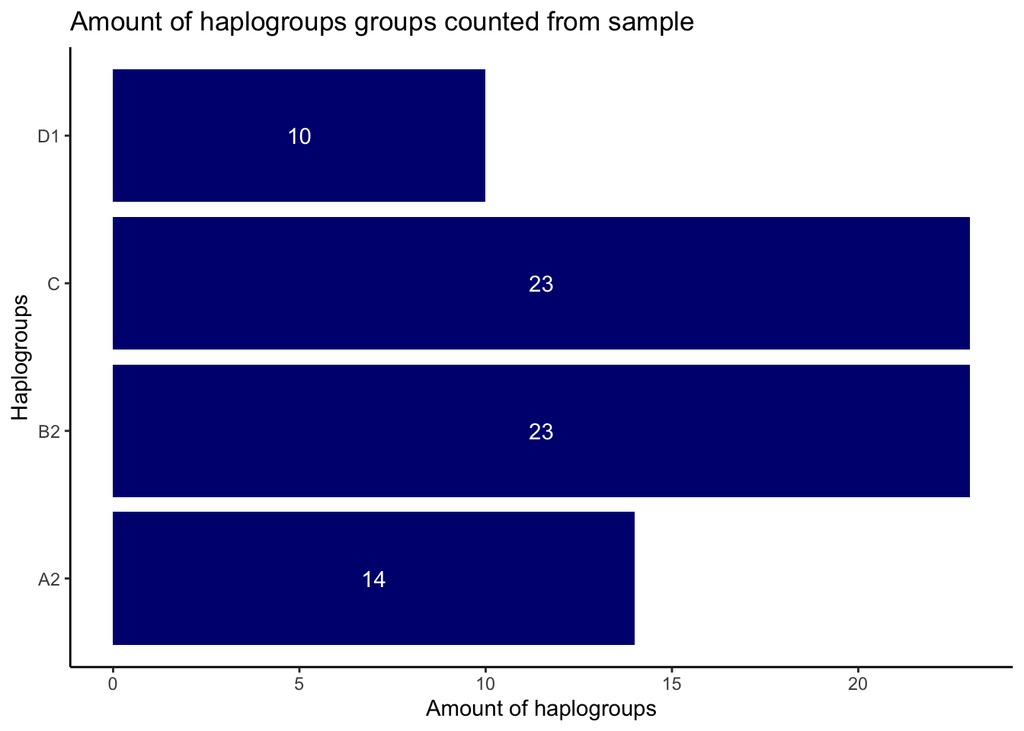

```r
#filtered data
new_mtDNA <- read_csv(here("data", "filtered_haploid.csv"))%>%
  mutate(new = str_sub(`Haplogroup(trim)`,start=1, end= 2))%>% #filtering row names for haplogroup for trim
  mutate(region= str_sub(SampleID, start = 5, end= 6))%>% # filter sample ID name to get region
  group_by(new)

#script for second plot
new_mtDNA%>%
  ggplot(aes(y= new))+
  geom_bar(fill= "navy blue")+
  geom_text(stat = "count", aes(label = ..count..),color = "white", position = position_stack(vjust = 0.5))+## this line isnt working
  theme_classic()+
  labs(x= "Amount of haplogroups",
       y= "Haplogroups",
       title= "Amount of haplogroups groups counted from sample")
```

# The locations where samples were taken from:

Samples were taken from different regions within Columbia and Peru.

- CL: Colombia
- NC: Northern Coast
- SC: Southern Coast
- NH: Northern Highlands
- SH: Southern Highlands
- TR: Amazonian ancestry that were buried in SH

# second plot

This stack plot shows the distribution of which haplogroup was found within each location. Within the stack plot, the amount of haplogroups counted for each region is labeled on the bar.

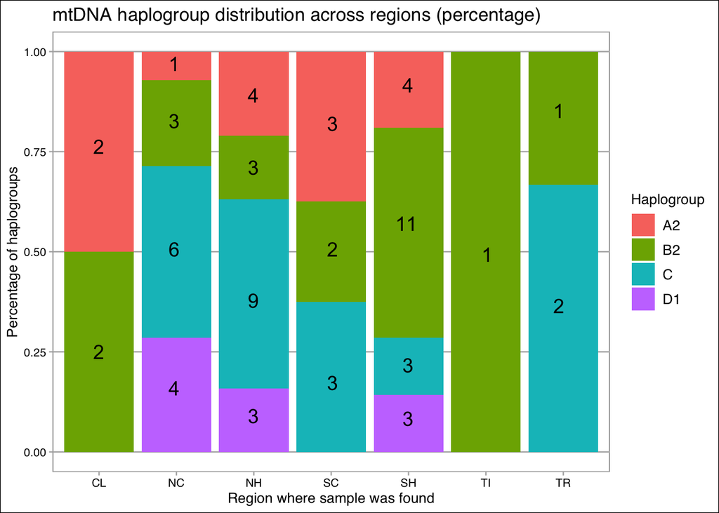

# Third Plot

The donut graph gives the viewers a different perception on amount of haplogroups found from samples used.

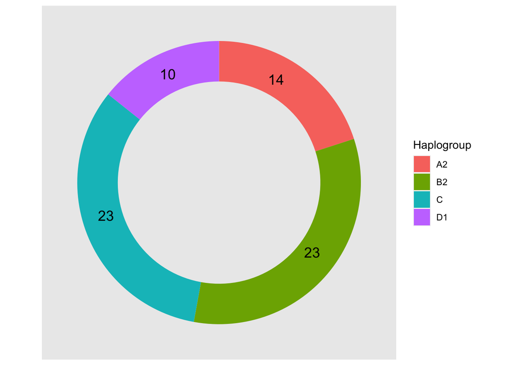

```r
### testing third plot, I HATE THIS!!!!!!!!!!!!!!
testing_mtDNAnew <- read_csv(here("data", "filtered_haploid.csv"))%>%
  mutate(new = str_sub(`Haplogroup(trim)`,start=1, end= 2))%>% #filtering row names for haplogroup for trim
  mutate(region= str_sub(SampleID, start = 5, end= 6))%>% # filter sample ID name to get region
  group_by(new)

test_mtDNA <- data.frame(region= c("A2", "B2", "C", "D1"),
  amount= c(14,23,23,10)
  )

test_mtDNA$fraction = test_mtDNA$amount / sum(test_mtDNA$amount)# Compute percentages

test_mtDNA$ymax = cumsum(test_mtDNA$fraction) # Compute the cumulative percentages (top of each rectangle)

test_mtDNA$ymin = c(0, head(test_mtDNA$ymax, n=-1)) # Compute the bottom of each rectangle

# Make the plot

donut <-
ggplot(test_mtDNA, aes(ymax=ymax, ymin=ymin, xmax=4, xmin=2, fill=region)) + #the fill=category makes my code stop
  geom_rect() +
  coord_polar(theta="y") + # Try to remove that to understand how the chart is built initially
  xlim(c(-3, 4))+ # Try to remove that to see how to make a pie chart
  theme(axis.text.x= element_blank(),
        axis.text.y= element_blank(),
        axis.line.x= element_blank(),
        axis.line.y= element_blank(),
        axis.ticks.y = element_blank(),
        panel.border = element_blank(),
        panel.grid.major = element_blank(),
        panel.grid.minor = element_blank())+
  scale_fill_discrete(name = "Haplogroup")

ggdraw(donut) + #uses plot to layer on top
draw_label("23", x = 0.59, y = 0.3, hjust = 0, vjust = 0,
           fontfamily = "", fontface = "plain", color = "black", size = 14,
           colour = "black")+
  draw_label("14", x = 0.52, y = 0.77, hjust = 0, vjust = 0,
             fontfamily = "", fontface = "plain", color = "black", size = 14,
             colour = "black")+
  draw_label("23", x = 0.19, y = 0.4, hjust = 0, vjust = 0,
             fontfamily = "", fontface = "plain", color = "black", size = 14,
             colour = "black")+
  draw_label("10", x = 0.31, y = 0.785, hjust = 0, vjust = 0,
             fontfamily = "", fontface = "plain", color = "black", size = 14,
             colour = "black")
```